# Constraint and Competition in Assemblages: A Cross‐Continental and Modeling Approach for Ants. | The American Naturalist: Vol 165, No 4

# Constraint and Competition in Assemblages: A Cross‐Continental and Modeling Approach for Ants

Catherine L. Parr

,

Brent J. Sinclair

,

Alan N. Andersen

,

Kevin J. Gaston

, and

Steven L. Chown

Editor: Jonathan B. Losos

, and

Associate Editor: Stephen B. Heard

1. Department of Zoology and Entomology, University of Pretoria, Pretoria 0002, South Africa;2. Spatial, Physiological and Conservation Ecology Group, Department of Botany and Zoology, University of Stellenbosch, Private Bag X1, Matieland 7602, South Africa;3. Commonwealth Scientific and Industrial Research Organisation Tropical Ecosystems Research Centre, PMB 44 Winnellie, Northern Territory 0822, Australia;4. Biodiversity and Macroecology Group, Department of Animal and Plant Sciences, University of Sheffield, Sheffield S10 2TN, United Kingdom

## Abstract

The mechanisms leading to structure in local assemblages are controversial. On the one hand, assemblage structure is thought to be the outcome of local interactions determined by the properties of species and their responses to the local environment. Alternatively, this structure has been shown to be an emergent property of assemblages of identical individuals or of random sampling of a regional assemblage. In ants at baits, a combination of environmental stress and interspecific competition is widely held to lead to a unimodal relationship between the abundance of dominant ants and species richness. It is thought that in comparatively adverse environments, both abundance and richness are low. As habitats become more favorable, abundance increases until the abundance of dominant ants is so high that they exclude those that are subordinate and so depress richness. Here we demonstrate empirically that this relationship is remarkably similar across three continents. Using a null model approach, we then show that the ascending part of the relationship is largely constrained to take this form not simply as a consequence of stress but also as a result of the shape of abundance frequency distributions. While the form of the species‐abundance frequency distribution can also produce the descending part of the relationship, interspecific competition might lead to it too. Scatter about the relationship, which is generally not discussed in the literature, may well be a consequence of resource availability and environmental patchiness. Our results draw attention to the significance of regional processes in structuring ant assemblages.

The mechanistic basis of variation in diversity remains a contentious topic in ecology. The debate can be characterized as one concerning the significance of local, deterministic processes, such as the operation of a set of assembly rules based on local interactions (Weiher and Keddy 1999), operating over small spatial and temporal scales, as opposed to the significance of regional processes that occur over larger areas and through evolutionary time (Ricklefs 2004). The application of null models in ecology has demonstrated that many of the patterns that have been attributed to such local interactions can arise independently of them (Gotelli 2000, 2001) and may well be a consequence of regional‐scale processes. Thus, two apparently divergent views on the processes structuring local communities exist: one emphasizing local mechanisms and the other emphasizing those occurring at regional scales (see Currie and Francis 2004; Qian and Ricklefs 2004). In consequence, several authors have emphasized that an understanding of the ways in which local and regional processes interact to determine the membership and properties of local assemblages, and therefore spatial variation in diversity, is one of ecology’s most pressing goals (Ricklefs 1987, 2004; Lawton 1999; Gaston 2000; Currie and Francis 2004; Simberloff 2004). Here we address this goal by examining one of the most significant assemblage‐level patterns in ants: the relationship between dominance and species richness, which has traditionally been regarded as the outcome of an interaction between local environmental stress and the extent of interspecific interactions.

The dominance‐impoverishment rule (Hölldobler and Wilson 1990) describes the relationship between ant species richness and dominant species in a community: the fewer ant species in a local community, the more likely the community is to be behaviorally dominated by one or two species with large, aggressive colonies. In many studies, however, the direction of this causality has been reversed, and emphasis has been placed on the effect dominants have on species richness, not vice versa (e.g., Andersen 1992; Andersen and Patel 1994; Morrison 1996; Retana and Cerdá 2000). The effect of dominance on species richness was examined in detail by Andersen (1992), who suggested that, at baits, the full relationship between species richness and dominance is unimodal. Species richness is low at very low levels of dominance, and as dominance increases, species richness also increases until a point is reached after which species richness declines as dominance increases. The ascending portion of the curve is thought to correspond to increasing habitat favorability for ants: in conditions considered marginal (or stressful) for ants, species richness and the abundance of dominant ants are low. As conditions begin to improve, the abundance of all ants begins to increase, as does species richness (see also Andersen 1995, 1997b). The descending part of this relationship is generally attributed to an increase in the abundance of dominant ants to such an extent that they reduce species richness via competitive exclusion (Andersen 1992; Morrison 1996). Indeed, interspecific competition is thought to be a key mechanism structuring local assemblages (Savolainen and Vepsäläinen 1988; Andersen and Patel 1994; Majer et al. 1994; Sanders et al. 2003), and it has been referred to as the “hallmark of ant ecology” (Hölldobler and Wilson 1990; though see also Ribas and Schoereder 2002; Gibb and Hochuli 2004).

While a unimodal or negative monotonic decline might indicate competition (Andersen 1992; Morrison 1996), the question of whether other mechanisms can give rise to the unimodal pattern has not been addressed. An alternative explanation to that of stress for the ascending part of the relationship is that high species richness and low dominance are possible only with a completely even abundance frequency distribution (which might itself arise for several reasons, including those that have little to do with competition; Tokeshi 1999; Gaston and Blackburn 2000; Hubbell 2001). Here, individuals are distributed evenly among species, which would result in low dominance, because all species would have similar abundances. Put simply, area *A* in figure 1 might be filled only if the assemblage has an abundance frequency distribution that is unrealistic (e.g., Gaston and Blackburn 2000). Thus, the observed, ascending part of the unimodal relationship is constrained to assume that form irrespective of the influence of habitat adversity or stress. Similarly, although competition has been assumed to reduce species richness at high dominance levels, an alternative explanation is that high dominance and high species richness (fig. 1, area *B*) are possible only with a very highly skewed abundance frequency distribution (where one species is very highly abundant and all other species have extremely low abundances, thus producing very low evenness; see Magurran 2003 for a discussion of evenness, richness, and their relationships and measurement). This is generally also considered unrealistic in most natural communities but particularly for insects (Halley and Inchausti 2002). If one species is highly abundant while the other species have very low abundances, over time it is likely that species with low abundances would go extinct, often for purely stochastic reasons (Gaston and Chown 1999). In other words, the form of the dominance–species richness relationship may not be a consequence of local interactions but of other processes operating at a regional level (as has been found for assemblages elsewhere; see, e.g., Caley and Schluter 1997; Blackburn and Gaston 2001; Smith 2001).

**Figure 1:**

Graphical representation of the unimodal relationship between dominance and species richness. *A*, Low dominance and high species richness; *B*, high dominance and high species richness; *C*, low to intermediate dominance and low species richness.

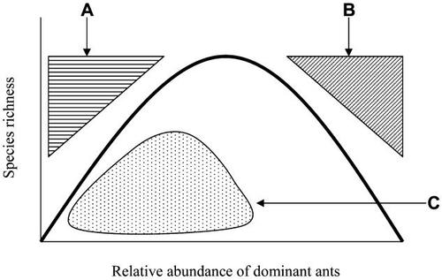

In addition, variability about the unimodal dominance‐richness relationship, which is clear in the few studies that have demonstrated the full pattern, is rarely considered (fig. 1, area *C*). In consequence, the cause of scatter around the unimodal pattern is not known. Potentially important factors that have received little attention in relation to ant dominance–species richness relationships are environmental patchiness (i.e., the distribution of resources) and the availability of resources. This omission is surprising given that natural systems are typically patchy and that environmental heterogeneity has been shown to be important in structuring communities (Kolasa and Rollo 1991; Wiens 2000). Here we explore each of these issues in turn by examining dominance–species richness patterns across a range of baiting trials on three continents, including within‐ and between‐habitat comparisons, and by simulating the distribution of ants among baits using a variety of realistic and unrealistic assemblage scenarios.

## Methods

### Study Sites and Field Sampling

#### South Africa.

Ant sampling was carried out on experimental burn plots that form part of a long‐term burning experiment initiated in 1954; unburned plots have had no fires since then. Plots are approximately 7 ha in size and are separated by firebreak roads. Within each habitat type, treatment plots representing a range of burn histories (including the two extreme treatments, unburned and annually burned) were replicated twice. Unburned plots are densely vegetated with moribund grass and a well‐developed litter layer, whereas annually burned plots are more open, with reduced ground cover and fewer trees (see Parr et al. 2004).

Baiting was conducted in the summer months of late November 2001 to early February 2002. In the summer rainfall region of South Africa, ants are most active and abundant at this time (Parr et al. 2004). Ant baiting was carried out on unburned and annually burned plots, replicated twice in each of the three savanna habitats. The relative behavioral dominance of species was quantified by observing ants at fish baits (Fellers 1987; Savolainen and Vepsäläinen 1988; Andersen 1992). Baiting was conducted in the early morning, midday, and late afternoon and for each time period was repeated at least three times. Baiting across a range of temperature regimes, in addition to different plot and habitat types, enabled a wide range of stress levels to be sampled. Large vertebrate carnivores precluded sampling at night.

#### Data Analysis.

Although there are no standard protocols for identifying dominant ants, dominance is usually defined in terms of either ecological dominance (a larger number of individuals) or behavioral dominance (displays of aggression toward other species such that they display avoidance behavior; see Andersen 1992; Cerdá et al. 1997). This study focused on ecological dominance to define dominant ants. Thus, dominant ant species are considered those that occurred at a large proportion of baits, numerically dominated and monopolized many of the baits where they occurred, and had high mean abundance scores (Andersen 1992; Morrison 1996; Cerdá et al. 1997). Although behavioral dominance was not explicitly tested for using observations of interspecific interactions at baits to produce a dominance index (see Fellers 1987), any interspecific aggression that was observed was noted. Dominant species were identified, and general dominance levels for each area were determined on the basis of the following descriptors (see Andersen 1992, 1997a; Morrison 1996; Cerdá et al. 1997): number of baits monopolized with >20 individuals of a species where they occurred and high mean abundance score.

### Modeling Ants at Baits

A model was developed using VisualBasic to simulate the distribution of ants at baits and to determine what conditions are necessary to generate different dominance and species richness combinations. The model consisted of two parts: a null simulation with no competitive exclusion at baits (i.e., the mechanism being tested is deliberately excluded; see Gotelli 2001) and a second simulation incorporating some degree of competitive interaction between species. In the null simulations (indicated as *Null*), there were no rules restricting the number of ants at baits; thus, no structuring mechanism is implied. Individuals were assigned to species using all three (even, skewed, and realistic) abundance frequency distributions, and the descriptors of dominance were varied as were occupancy frequency distributions (even or Poisson distribution) at baits (Table 1). Competition (models indicated as *Competition*) was incorporated into the simulation using two rules. First, the number of species that could co‐occur at a bait was restricted to four, and second, if the abundance of any species at a bait was >20 (i.e., abundance score of >4), no other species were allowed to co‐occur at the bait. Patchiness was then introduced into the model in several different ways (see app. A), leading to two competition models (Table 1). Both *Null* and *Competition* simulations used 14 ant species and up to 15 baits. These values were chosen because in KNP, the maximum number of species recorded during a baiting session was 14, and 15 baits were deployed during each baiting session. The total abundance of ants in the starting pool (*a*) ranged from 50 to 2,500.

**Table 1:**

Dominance measures and degree of patchiness used in each of the simulations

| Model | Dominance measure |  |  | Patchiness type |  |  |
| --- | --- | --- | --- | --- | --- | --- |
|  | Mean abundance only | Monopolization only | Mean abundance and monopolization | Even bait distribution | Poisson bait distribution | Number of baits limited (two to 15 baits) |
| *Null 1* |  |  | X | X |  |  |
| *Null 2a* | X |  |  | X |  |  |
| *Null 2b* |  | X |  | X |  |  |
| *Null 3* | X |  |  |  | X | X |
| *Competition 1* |  |  | X | X |  | X |
| *Competition 2* |  |  | X |  | X | X |

Once an individual from the pool had a species identity, this individual was then assigned to a bait. Depending on the model specifications to assign individuals to baits, either a random, uniform distribution (equal chance of being assigned to any bait) or a nonrandom distribution (chance of being assigned to a bait is not equal because some baits are more likely to attract ants than others because of factors such as differing proximity of baits to nests) was used. The nonrandom distribution also incorporated variability in the abundance of ants at baits (see app. A). Aggregated distributions, which are common in nature, are often best described by the negative binomial distribution (NBD; Taylor et al. 1978; Warren et al. 2003). The parameter *k* of the NBD was calculated to determine whether the abundance scores of ants at baits (using KNP field data for each area separately and combined) were aggregated. All values for *k* were, however, relatively high (3.8–6.14 as opposed to 0.01–0.6; see Warren et al. 2003), which indicated that abundance scores at baits were less aggregated than is commonly found for arthropod assemblages. Moreover, because the frequency distribution for abundance scores did not differ significantly from a Poisson distribution, this distribution was used for the assignment of ants to baits.

Once all ants in the starting pool had been assigned to baits, raw abundances for each species at each bait were transformed to abundance scores based on the same scoring system (0–6) used by Andersen (1997a). The abundance scores of all species that were considered dominant, based on the descriptors we used previously, were summed (thus providing a total abundance score for dominants), and species richness was determined for all baits occupied. Numerically dominant ant species were identified either as those that had high mean abundance scores or as those that monopolized many of the baits at which they occurred, or both, depending on the model specifications (see also Andersen 1992, 1997a; Morrison 1996; Cerdá et al. 1997). This “either/or” approach differed from the descriptors used for the field data but only for the null models because monopolization was always absent therein. Nonetheless, competitive models were always based on both descriptors (Table 1), and null models using abundance descriptors are unlikely to bias our results only to the extent that the null models are uninformative (see app. A for further information). For a species to monopolize a bait, it had to be the only species at the bait, and there had to be >20 individuals of that species at the bait (i.e., score of >4 in the system developed by Andersen [1997a]). Both measures were calculated only for baits where species are recorded, and thus zeros (species absences) in the data were excluded. This is common practice in ant studies and therefore importantly enables direct comparison of the results from this modeling exercise with studies that have investigated dominance–species richness patterns (e.g., Andersen 1992, 1997a; Cerdá et al.1997).

For each species, a mean abundance score was calculated by dividing the sum of the abundance scores for the species at all baits by the number of baits at which the species was present, and the percentage of baits monopolized (excluding zeros) was calculated. Dominant species were classified as those with a mean abundance of >3.2, as those that monopolized >22.9% of baits where they occurred, or both, depending on model specifications. These values were based on thresholds from field baiting data (see Table 2).

**Table 2:**

Occurrence of dominant and subordinate ants at baits in Kruger National Park

|  | Baits recorded (%) |  |  | Baits monopolized (%) |  |  | Mean abundance scorea |  |  |
| --- | --- | --- | --- | --- | --- | --- | --- | --- | --- |
|  | M | S | P | M | S | P | M | S | P |
| Dominant: |  |  |  |  |  |  |  |  |  |
| *Pheidole* spp. | 27.5 | 53.0 | 17.8 | 35.7 | 60.8 | 40.0 | 3.80 | 4.06 | 3.21 |
| *Crematogaster* spp. | 6.9 | 1.1 | 30.0 | 54.3 | 50.0 | 23.0 | 4.09 | 4.93 | 3.62 |
| *Myrmicaria natalensis* | 11.2 | 14.5 | 19.3 | 64.5 | 33.3 | 33.3 | 3.36 | 4.22 | 3.30 |
| *Anoplolepis custodiens* | … | 1.7 | 5.1 | … | 88.9 | 26.1 | … | 3.93 | 4.06 |
| *Monomorium emeryi* | 8.8 | … | … | 55.6 | … | … | 3.88 | … | … |
| Nondominant: |  |  |  |  |  |  |  |  |  |
| *Camponotus* spp. | 11.8 | 5.1 | 14.0 | 3.3 | 0 | 1.6 | 1.45 | 1.53 | 1.55 |
| *Polyrhachis* spp. | 5.9 | 11.0 | 18.7 | 0 | 0 | 0 | 1.46 | 1.52 | 1.39 |

Note: Data are for morning and afternoon readings only.

<sup>a</sup>Mean abundance scores range from a possible minimum of 1 (always a single ant recorded whenever the species occurred) to a possible 6 (always >50 ants whenever the species occurred).

To explore a reasonably broad range of outcomes possible for each model, each simulation was iterated 100 times. All dominance and species richness values obtained from the 100 iterations were then plotted to determine how the relationship varied; these values often converged on the same value, although this was not always the case. In addition, to explore the sensitivity of the models to changes in the assumptions and to the inclusion of recruitment, a suite of additional model runs was undertaken (see app. A).

The extent to which the model simulations could produce an upper bound and variability in the dominance‐richness relationship similar to that of the field data was investigated by using quantile regressions (Cade and Noon 2003) with the Blossom statistical package (available from U.S. Geological Survey, http://www.fort.usgs.gov/products/software/blossom/blossom.asp). Specifically, the field data for all continents were compared with the outcome of *Competition 1* with a realistic abundance frequency distribution. Quantile regression parameters were compared between the field and model data using an inverted permutation and hypothesis testing approach (Cade and Richards 1996, 2001). Parameters where 95% confidence intervals overlapped were not considered significantly different.

## Results

### Field Sampling

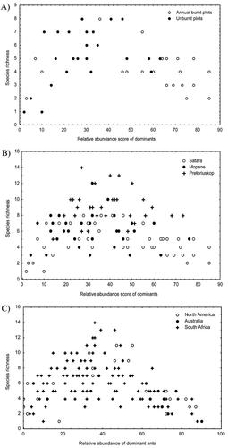

### Model Results

Not unexpectedly, the outcomes of the null model (i.e., excluding competition) simulations varied substantially depending on the conditions (see app. A). Most notably with model *Null 3* it is possible to have high dominance and high species richness (maximum value of 14 species) with a realistic abundance frequency distribution when there are no competitive rules operating (fig. 3A). A similarly broad range of outcomes, which varied depending on the conditions, was produced with the competitive model simulations (see app. A). Take note that dominance values of 0 with high richness could be produced in these models (the values on the upper portion of the *Y*‐axis), but these were a function of *a*; when a low starting abundance of ants was specified, there were insufficient individuals for the mean abundance score to be >3.2 and for a species’ score a bait to be >4 (necessary to meet the monopolization rule). Thus, dominance values >0 did not occur because the dominance descriptors were not met. In other words, when ants occur, all do so at very low abundances (though relative abundances might differ), which is atypical of natural systems. Thus, we exclude consideration of these points. The key outcomes were as follows. In *Competition 1*, high species richness and low dominance were possible only with an even abundance frequency distribution (fig. 3B). Neither area *A* nor area *B* in figure 1 could be filled (especially below a dominance value of 20) when using realistic or skewed abundance frequency distributions (see app. A). In the case of *Competition 2*, even with a realistic abundance frequency distribution, area *A* in figure 1 still cannot be filled, and although values of both dominance and species richness tended to be intermediate, some simulations resulted in high dominance and high species richness (fig. 3C). Increasing competition at baits by altering the abundance threshold for co‐occurrence in *Competition 3* resulted in a reduction in species richness and a wider range of dominance values with an even bait distribution and generally reduced species richness with a Poisson bait distribution (figs. B7, B8 in app. B). In *Competition 4*, using a Poisson bait distribution and a realistic abundance frequency distribution, when the number of species allowed to coexist at baits was increased (from four to five species), both species richness and dominance increased (fig. B10B).

**Figure 3:**

Relationship between species richness and abundance of dominant ants at baits for (*A*) *Null 3* model using a realistic abundance frequency distribution, (*B*) *Competition 1* using an even abundance frequency distribution, and (*C*) *Competition 2* using a realistic abundance frequency distribution. Each data set represents the result of 100 iterations of the model.

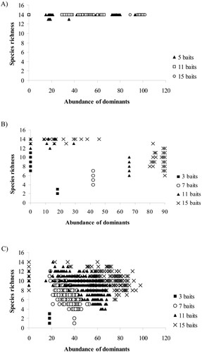

Sensitivity analyses for the dominance rules (mean abundance and monopolization values) indicated that simulations were generally insensitive to alteration of dominance thresholds. In addition, adding recruitment into the simulations did not affect the overall findings from the different models (see app. A for both dominance sensitivity analyses and recruitment).

### Comparison of Variability between Field and Model Data

None of the 0.99 quantile regression parameters for the field data including all continents and the output of *Competition 1* with a realistic abundance frequency distribution was significantly different (Table 3). Therefore, our models can produce an upper bound of the form typical of the field data. However, the parameters for the other quantiles typically differed significantly, indicating that the models do not always reproduce the scatter under the upper bound in the field data (fig. 4).

**Table 3:**

| Estimates for parameters | Quantile |  |  |  |  |
| --- | --- | --- | --- | --- | --- |
|  | .01 | .1 | .5 | .9 | .99 |
| Model: |  |  |  |  |  |
| *a* | 1 | 1.0808 | 2.1055 | −.4108 | 3.4168 |
| *b* | −1 × 10<sup>−17</sup> | −.101 | −.0126 | .2256 | .3362 |
| *c* | 2 × 10<sup>−19</sup> | .0003 | .0003 | −.0021 | −.0039 |
| Field: |  |  |  |  |  |
| *a* | −.1893a | .0 NS | 1.9000 NS | 4.8004a | 10.6267 NS |
| *b* | .1327a | .2091a | .2807a | .2923 NS | .2194 NS |
| *c* | −.0014a | −.0025a | −.0034a | −.0035a | −.0035 NS |

<sup>a</sup>Parameter estimates do differ significantly between field and model.

**Figure 4:**

Fitting of quantiles to (*A*) field data (data from all continents included) and (*B*) model data (*Competition 1*, realistic abundance frequency distribution).

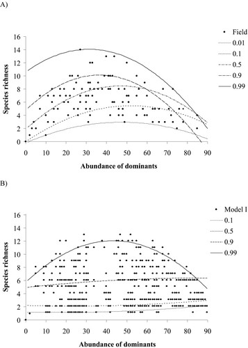

## Discussion

Field baiting data for South Africa produced a unimodal relationship between dominance and species richness, albeit with considerable variation in baiting sessions resulting in several values lying between the upper and lower bounds of this relationship. Nonetheless, the unimodal pattern was consistent across all three habitats in the KNP despite the rather different characteristics of their habitats and ant assemblages (Parr et al. 2004). Even more remarkably, the unimodal pattern was also consistent across the three continents on which similar baiting trials were undertaken (fig. 2). Indeed, the fact that it was possible to plot results from baiting trials in South Africa, North America, and Australia on the same graph serves to emphasize how similar the pattern is among these very different biotas. Therefore, the unimodal relationship between dominance and species richness at baits appears to be general.

The cross‐continental similarity in assemblage structure found here is striking and immediately begs the question of whether the outcomes of the baiting trials are constrained to take a unimodal shape owing to the form of abundance frequency distributions. If this is the case, then the similarity is of little interest because it provides no evidence of general mechanisms beyond those responsible for producing skewed abundance frequency distributions in any assemblage (see Tokeshi 1993; Gaston and Blackburn 2000; Hubbell 2001). However, if this is not the case, then one or more additional mechanisms might well be responsible for the pattern. In particular, the main contenders for this role are interspecific competition at high dominance levels and environmental stress where dominance is low. Andersen (1992, 1997b) came out strongly in favor of these two mechanisms, and they have since been widely accepted in the literature (Retana and Cerdá 2000; Albrecht and Gotelli 2001).

Our models suggest that the patterns might be the outcome of a variety of processes and may be constrained to take this form. Indeed, quantile regression and particularly the 0.99 quantile served to emphasize the similarity in unimodal form between field and model data (fig. 4). Before discussing the outcomes of the models in detail, it is important to note that, like all models, the ones used here make several assumptions (including species equivalence, consistency of behavior, and patterns of dominance relative to abundance; see Bestelmeyer 2000), the effects of which remain to be fully explored in the field situation. Moreover, we have not explored the full range of variation in abundance frequency distributions that might be characteristic of ant assemblages. Nonetheless, our models produce remarkably consistent outcomes under a wide range of conditions (see app. A) that provide several testable hypotheses regarding the potential mechanisms structuring ant assemblages.

### The Ascending Part of the Relationship

These simulations revealed that it is possible to have high species richness and low dominance (the upper portion of area *A* in fig. 1) only with an even abundance frequency distribution (fig. 3B; app. A) or with very high co‐occurrence levels (e.g., 14 species at three baits). Because such co‐occurrence levels are entirely unrealistic (i.e., no competition between ants, as in *Null 3*, is unrealistic), and because an even abundance frequency distribution is biologically unlikely (Tokeshi 1999; Gaston and Blackburn 2000), a situation with high species richness and low dominance is improbable. Therefore, it appears that the ascending part of the unimodal relationship is largely constrained to take this form. In other words, stress is not required to produce low richness and dominance (as is often assumed; Andersen 1995, 1997b; Morrison 1996; Bestelmeyer 1997), but rather this combination could be a function of the way in which community assembly leads to a skewed abundance frequency distribution (see Tokeshi 1993, 1999; Bell 2001, 2003; Hubbell 2001; Sugihara et al. 2003). These results are in keeping with a growing literature indicating that regional processes play a significant role in generating local assemblage structure (Caley and Schluter 1997; Lawton 1999; Blackburn and Gaston 2001; Ricklefs 2004).

However, the simulations also suggest that stress could play a role in producing a positive relationship between richness and dominance at low dominance values. In those simulations (null and competitive) where ant abundance was held low and ants were constrained to just a few baits, there was a strong positive relationship between dominance and richness at low dominance levels for realistic and skewed abundance frequency distributions. Thus, any factor that results in low abundances and patchy distributions could also produce the ascending portion of the unimodal curve, without assuming an unrealistic abundance frequency distribution (e.g., fig. 4). Environmental stresses, such as limited food availability, lack of nesting sites, and extreme temperatures, reduce ant abundance (Andersen 1995, 2000; Cerdá et al. 1998; Bestelmeyer 2000), and consequently bait occupancy, and could therefore result in the positive relationship between dominance and richness. The fact that area *A* in figure 1 remains unoccupied as a consequence of the form abundance frequency distributions are constrained to take, as an effect of stress, or as some combination of the two may reflect the combination of local and regional effects. The form of the abundance frequency distribution is likely to set the upper bound to the ascending part of the dominance‐richness relationship, while stress, resulting in low abundances and patchy distributions, might further alter it.

### The Descending Part of the Relationship

Without competitive interactions, both dominance and species richness were generally high. When competition was introduced into the model, high dominance and high species richness (fig. 1, area *B*) were possible with an even abundance frequency distribution and very high ant abundances (fig. 3B; app. A). However, under these conditions, the number of species at baits was high, and all or the majority were dominants and had high abundances, a situation that is not realistic. Under natural circumstances, there is seldom more than one species dominant at a bait after 60 min (e.g., Bestelmeyer 2000), and where there is more than one species dominant across a number of baits in a given area at one time, the number of species coexisting at a bait is low (e.g., <3; C. L. Parr and A. N. Andersen, unpublished data). Thus, an absence of baits with high richness and dominance could be a consequence of the constraints associated with the shape of abundance frequency distributions.

However, the simulations indicated that it is also possible to have high dominance and high richness in a competitive situation with a realistic abundance frequency distribution, high ant abundance, many baits occupied, and a weighted, rather than uniform, occupancy frequency distribution (or the way in which ant species differentially occupy baits; fig. 3C; app. A). The high level of bait occupancy and high abundance coupled with at least some measure of aggregation meant that although dominant ants controlled some of the baits, at least several other baits could support a variety of nondominant species (and also occasionally dominant species at low abundances). That this was the case is clearly shown by the relaxed competition model, which tended to result in even higher richness at high dominance levels, and the intensified competition model, in which the reduction in the number of ants that could co‐occur at a bait strongly depressed species richness. Indeed, these outcomes also suggest that the mechanism underlying the presence of both high dominance and richness is similar to the aggregation model of coexistence proposed by Atkinson and Shorrocks (1981, 1984). In this model, developed originally for species on patchy, ephemeral resources and since supported in many taxa (Ives 1991; Giller and Doube 1994; Kouki and Hanski 1995; Krijger and Sevenster 2001), higher levels of intraspecific competition relative to interspecific competition enable inferior competitors to coexist. Thus, high species richness can be maintained. The simulations suggest that the upper right‐hand portion of the dominance‐richness space can be filled given a scenario that might be considered realistic for a variety of organisms.

If this space can be filled under a biologically realistic scenario, the question remains as to why the combination of high richness and dominance is so uncommon for ant assemblages. One reason might be that interspecific competition is much more pronounced than intraspecific competition in ants, so it makes coexistence via an aggregation model of the kind proposed by Atkinson and Shorrocks (1981, 1984) unlikely. This does seem to be the case. Usually, ants from the same colony do not compete against each other but rather recruit additional nestmates to food resources (Hölldobler and Wilson 1990). Moreover, in our models in which interspecific competition was increased, or where competition was pronounced in the absence of low levels of aggregation, high dominance was never accompanied by high richness (see app. A; fig. B7). Therefore, it is clear that interspecific competition of the form envisaged by Andersen (1992, 1997b), and accepted by several other workers, can also produce the descending part of the dominance‐richness relationship (see fig. 4). Once again, it appears that regional processes might constrain the dominance‐richness relationship to a given form, while local factors, such as competition, are likely to alter it further. Thus, interspecific competition can still be considered a hallmark of ant ecology (Hölldobler and Wilson 1990).

### The Area between the Bounds

The model showed that patchy occurrence of ants at baits can result in variation between the upper and lower bounds in the central area of the unimodal relationship (fig. 1, area *C*). Reducing occupancy at baits resulted in a variety of outcomes especially at intermediate dominance levels (app. A; e.g., fig. B3B), producing variation similar to the field data but not identical to it (figs. 2, 4; Table 3). While Gotelli and Ellison (2002) suggest that unoccupied baits (patchiness) reflect nonlimiting resources, our data and models indicate that the converse might also be true (see also Palmer 2003). As the number of baits occupied increases, the starting abundance of ants (*a*) must also increase; otherwise, dominance is 0. Therefore, bait occupancy is likely to be proportional to resource availability. Increased foraging intensity of ants in areas of high resource availability (Sanders and Gordon 2002) lends further support to this idea. Although this study cannot unequivocally demonstrate the influence of resource availability on bait occupancy (especially because model data and field data produced rather different quantile regression values), these simulations do draw attention to the importance that patchiness might have as a mechanism generating the scatter of points in dominance‐richness relationships.

### Conclusions

The unimodal relationship between dominance and richness in ant assemblages appears to be characteristic of ant assemblages across a wide variety of scales. However, like other such relationships, there is substantial variation about it, which appears to be a consequence of resource availability and patchiness. Moreover, the form of the upper bound to the relationship is likely constrained by those processes that lead to skewed abundance frequency distributions, while local factors such as variation in abundance (which could be a consequence of stress) and interspecific competition can substantially modify it. What the relative contribution of each of these factors is likely to be has yet to be determined, but the similarity of assemblages across three continents suggests that regional processes deserve further scrutiny. This finding is in keeping with work on a wide variety of other assemblages (Caley and Schluter 1997; Lawton 1999; Blackburn and Gaston 2001; Smith 2001; Ricklefs 2004).

## Acknowledgments

We thank A. Liedloff and R. Mercer for assistance with the figures. B. Bestelmeyer, M. McGeoch, and an anonymous reviewer provided useful and constructive comments that substantially improved the manuscript. This work was supported by a Department of Science and Technology Centre of Excellence for Invasion Biology grant to S.L.C., a University of Pretoria doctoral grant to C.L.P., National Research Foundation Science Liaison grants to C.L.P. and A.N.A., a New Zealand Science and Technology Postdoctoral Fellowship to B.J.S., and an Ellerman Foundation award from the University of Stellenbosch to K.J.G.

## Appendix A Modeling Ants at Baits

### Description of Null and Competitive Model Types Used in the Simulations

#### Null Models

In these simulations, there were no rules restricting the number of ants at baits; thus, no structuring mechanism is implied. Individuals were assigned to species using all three (even, skewed, and realistic) abundance frequency distributions. In model *Null 1*, for a species to be classified as dominant, it had to meet both the abundance and monopolization dominance descriptors. In *Null 2a* and *Null 3*, a species was classified as a dominant based only on the mean abundance threshold (i.e., a species was classified as dominant if it had a mean abundance score of >3.2, but monopolization was not considered). In *Null 2b*, a species was classified as a dominant based only on the percentage of baits that were monopolized (i.e., a dominant species had to monopolize >22.9% of baits where it occurred, but the mean abundance score was not considered). Ants were assigned to baits using either a random, even bait distribution or a Poisson distribution (see Table 1). Model *Null 2a* had an even bait distribution, while *Null 3* had a Poisson bait distribution, and the number of baits occupied was limited to simulate vacant baits observed in the field (i.e., varying bait occupancy).

#### Competitive Models

Competition was incorporated into the simulation using two rules. First, the number of species that could co‐occur at a bait was restricted to four (based on the maximum number of species found at a bait during field baiting in Kruger National Park [KNP]) and second, if the abundance of any species at a bait was >20 (i.e., abundance score of >4), no other species were allowed to co‐occur at the bait. All ants from other species at that bait were removed and returned to the pool to be reallocated to species and baits. The model did not allow for insinuators, that is, subordinate species that are able to coexist at baits with high numbers of dominants (see Wilson 1971). In all competitive models, dominance was determined using both mean abundance and monopolization dominance measures.

Patchiness in ant occurrence at baits was introduced into the model in two stages. First, model *Competition 1* limited the number of baits that could be occupied by ants (two to 15 baits depending on the model specification) while keeping the distribution at baits uniform and second, additional patchiness was introduced in model *Competition 2* such that the number of baits that could be occupied was limited (two to 15 baits), and ants were assigned to baits using a Poisson distribution (Table 1). Although competition, which can create monopolization at baits, is factored into these models by setting the threshold for the abundance at which species cannot co‐occur to >20 individuals (abundance score of 4), highly aggressive species may require only a few individuals to effectively control a bait. Thus, a further model, *Competition 3*, was based on *Competition 2* but simulated the effect of increasing competition by using thresholds of >5 and >10 ants per bait (rather than >20) to limit co‐occurrence for the monopolization rule. Decreasing the threshold for abundance of ants necessary for monopolization thus simulates the effect of increasing competitive ability. In addition, in model *Competition 4*, the number of species allowed to coexist at a bait was altered (three and five species per bait rather than four species) to simulate the effect of increased competition via a different route in the model. For both models altering co‐occurrence thresholds and species coexistence, simulations were run for both bait distributions, for all abundance frequency distributions, and for 15 baits using starting abundances of 250, 500, and 750.

#### Sensitivity Analyses

Sensitivity analyses for dominance thresholds were performed for models *Competition 1* and *Competition 2* (for even and Poisson bait distributions, respectively) using all three abundance frequency distributions (even, Poisson, and skewed) and 15 baits. Models were rerun with mean abundance score thresholds of 2.8 and 3.8 and with the monopolization percentage threshold set at 15% and 30%.

#### Recruitment Model

Because recruitment is a fundamental feature of ant communities (Hölldobler and Wilson 1990), some degree of recruitment needs to be included in the model. Recruitment was initially incorporated into the models via abundance frequency distributions for highly abundant species that recruit well and for species with low abundance that do not recruit well. However, to investigate recruitment of highly abundant species that do not recruit well and species with low abundance that do recruit well, a recruitment model was developed based on *Competition 1* and *Competition 2* (i.e., for both bait distributions). Recruitment (or assignment of ants to baits) was manipulated using a recruitment factor (RF), which was the number of conspecifics attracted to a bait for every individual of a species. The RF values were 1, 5, 10, and 20. Simulations were run for Poisson and skewed abundance frequency distributions and for 15 baits with a starting abundance of 750.

### Model Results

#### Null Models

Random, unrestricted assignment of ants to baits means that monopolization of baits (according to the threshold specified in the model) does not occur (there will either always be at least one other species present at any given bait or abundance will be so low that the threshold of >20 individuals set for monopolization will not be reached). Hence, in models *Null 1* and *Null 2b*, there was no dominance. Thus, when there were no competitive rules, dominance could only be quantified using mean abundance score. Therefore, only models using mean abundance score are considered below.

In the null simulations, because there are no rules limiting dominance levels, the maximum dominance attainable was dependent on the starting abundance (and bait occupancy). At lower abundances, there were insufficient ants (once distributed among species and baits) for any ant species to be classified as dominant based on mean abundance score. When the starting abundance of ants (*a*) was sufficiently large, dominance could be attained, but it was considerably higher than observed in the field. With an even distribution, dominance was achieved only when the starting abundance of ants was very large (when a threshold *a* > ∼2,000). For model *Null 2a*, when individuals were assigned to species using skewed and realistic distributions, the outcome was high species richness (13–14 species) and a range of dominance values from the minimum to very high (>90). Dominance increased with increasing abundance.

There was much greater variation in species richness with the null simulation that incorporated both types of patchiness (*Null 3*). With an even distribution, the abundance of ants required for dominance was low when bait occupancy was low (e.g., for dominance with five baits occupied, the minimum *a* value required for dominance was approximately 500). However, if all baits were occupied, dominance was possible only with very high abundances (figs. B1A, B2A). While dominance varied, species richness did not and remained at 14 species regardless of abundance of ants or bait occupancy.

For both skewed and realistic abundance frequency distributions, when bait occupancy was held constant, the effect of decreasing *a* was reduced dominance and lower, more variable species richness (fig. B1B, B1C; fig. B2B, B2C). As bait occupancy increased, dominance also tended to increase (fig. B1B, B1C). In addition, as the abundance of ants declined (fig. B2B, B2C), species richness also declined and was more variable. This effect was most pronounced for a skewed distribution.

#### Competition 1

As with subsequent models, dominance values of 0 were possible with any frequency distribution. Zero dominance values were a function of *a*; when a low starting abundance of ants was specified, there were insufficient individuals for the mean abundance score to be >3.2 and for a species’ score a bait to be >4 (necessary to meet the monopolization rule). Thus, dominance values >0 did not occur because the dominance descriptors were not met. For all frequency distributions, the effect of varying the abundance of ants was that dominance tended to increase with increasing abundance (figs. B3, B4; although there was sometimes considerable variation in species richness and dominance values for a given *a*).

With an even distribution, high species richness and low dominance were one possible outcome (where increasing both the number of baits occupied and abundance of ants elevated dominance and species richness but reduced variability in species richness; figs. B3A, B4A). This outcome was realized because only a very low number of baits (usually one) was monopolized. Another outcome using an even distribution was that with low bait occupancy, dominance and species richness were also low, and as occupancy increased, so did dominance and species richness. Thus, with all 15 baits occupied, dominance was high, and species richness ranged from six to 13 species. For a given bait occupancy, species richness values were always more variable than those for dominance, and the range of species richness values increased with the number of baits. This outcome was achieved because each bait was monopolized by one species, thus reducing species richness. However, with an even distribution, simulations indicating high dominance were unrealistic because the number of ant species was similar to the number of dominant ants and was always relatively high. High richness and dominance were a function of excluding the zeros when analyzing the dominance measures per species. Because species absences are excluded from the analyses when calculating dominance, an even distribution can result in the majority of (or all) species being dominant. This is extremely unlikely under natural circumstances and indeed makes the term dominant meaningless.

#### Competition 2

Using the *Null* and *Competition 1* models, it is possible to place data points only on the periphery of the unimodal dominance–species richness distribution found with field baiting data. Both patchiness measures (number of baits that are occupied and differential chance of these baits attracting ants) were used in this *Competition 2*. As with previous simulations, as bait occupancy increased (corresponding to decreased patchiness), dominance, and to a lesser degree species richness, increased (most noticeably with an even distribution; figs. B5A, B6A). None of the three abundance frequency distributions resulted in high dominance and low species richness. Intermediate to high dominance combined with low species richness could not be achieved using an even abundance frequency (figs. B5A, B6A). When dominance was low, the full range of species richness values was possible, but as dominance increased, species richness increased, and its variation declined. High dominance and high species richness were found when most or all species were dominant, which is highly unlikely in the field.

Using a skewed distribution, the dominance value did not exceed 80, and it was not possible to have high species richness and relatively low dominance (figs. B5C, B6C). Using a realistic distribution (figs. B5B, B6B), values of both dominance and species richness tended to be intermediate, with some simulations giving low dominance and low species richness, while others resulted in high dominance and high species richness. Five percent of these data points had dominance scores of >90 because, on occasion, several species per simulated baiting session met the monopolization descriptors. Increasing the monopolization threshold would reduce the number of baiting sessions with dominance scores of >90. As with *Competition 1*, high dominance required a combination of high ant abundance and high bait occupancy.

#### Competitions 3 and 4

Changing the number of individuals necessary for monopolization of a bait (figs. B7, B8) had a much greater effect than altering the rule restricting the number of species able to coexist at a bait (figs. B9, B10). The effect of increasing competition (i.e., reducing the number of individuals needed to monopolize a bait) was most pronounced for a realistic abundance frequency distribution using both bait distributions (figs. B7B, B8B). The result of increasing competition was a decline in species richness (even bait distribution) and reduced dominance (both bait distributions). With a realistic abundance frequency distribution and a Poisson bait distribution, when the number of species coexisting at a bait was increased, the result was increased dominance and species richness (fig. B10B).

#### Sensitivity Analyses

Sensitivity analyses for *Competition 1* in which mean abundance and monopolization thresholds were altered indicated that for all three abundance frequency distributions, the simulations were insensitive to changes in these values (figs. B11, B12). The same was true of *Competition 2* (figs. B13, B14).

## Appendix B Figures

**Figure B1:**

Effect of changing bait number on the relationship between species richness and abundance score of dominant ants for three species abundance frequency distributions using the *Null 3* model, which includes patchiness within baits and alters the number of baits that are occupied. Number of baits occupied: five, 11, and 15 baits. Starting values for *a* ranged from 100 to 2,500. Each data set is the result of 100 iterations of the model. *A*, Even abundance frequency distribution; *B*, realistic abundance frequency distribution; *C*, skewed abundance frequency distribution.

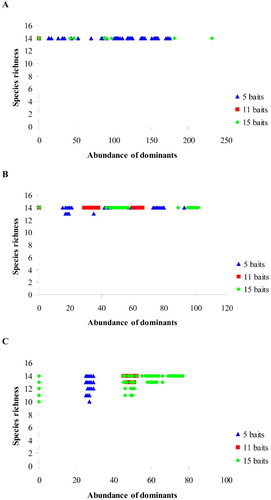

**Figure B2:**

Effect of changing starting abundance of ants on the relationship between species richness and abundance score of dominant ants for three species abundance frequency distributions using the *Null 3* model, which includes patchiness within baits and alters the number of baits that are occupied. Number of baits occupied: five, 11, and 15 baits. Starting values for *a* ranged from 100 to 2,500. Each data set is the result of 100 iterations of the model. *A*, Even abundance frequency distribution; *B*, realistic abundance frequency distribution; *C*, skewed abundance frequency distribution.

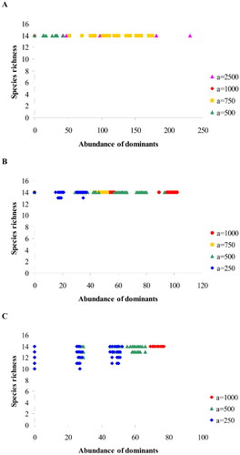

**Figure B3:**

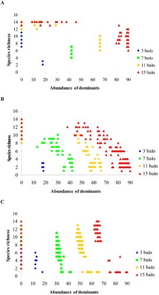

**Figure B4:**

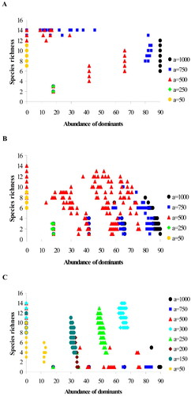

**Figure B5:**

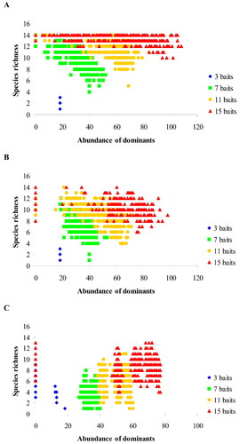

**Figure B6:**

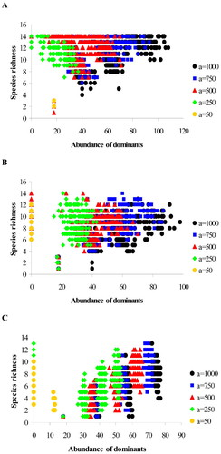

**Figure B7:**

Effect of changing threshold number of ants required to monopolize a bait on the relationship between species richness and abundance score of dominant ants using a competitive model (*Competition 3*) that simulates increased competition by decreasing the threshold number of ants required to achieve dominance. An even bait distribution and 15 baits were used, with the dominance threshold varied. Each data set is the result of 100 model iterations. *A*, Even abundance frequency distribution; *B*, realistic abundance frequency distribution; *C*, skewed abundance frequency distribution.

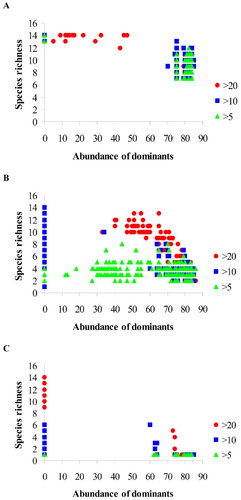

**Figure B8:**

Effect of changing threshold number of ants required to monopolize a bait on the relationship between species richness and abundance score of dominant ants using a competitive model (*Competition 3*) that simulates increased competition by decreasing the threshold number of ants required to achieve dominance. A Poisson bait distribution and 15 baits were used, with the dominance threshold varied. *A*, Even abundance frequency distribution; *B*, realistic abundance frequency distribution; *C*, skewed abundance frequency distribution.

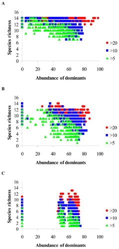

**Figure B9:**

Effect of modifying the number of species able to coexist at a bait on the relationship between species richness and abundance score of dominant ants using a competitive model (*Competition 4*) that simulates altered competition by modifying the number of species able to coexist at a bait. An even bait distribution and 15 baits were used, with the dominance threshold varied. Each data set is the result of 100 iterations of the model. *A*, Even abundance frequency distribution; *B*, realistic abundance frequency distribution; *C*, skewed abundance frequency distribution.

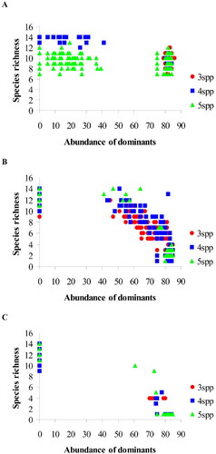

**Figure B10:**

Effect of modifying the number of species able to coexist at a bait on the relationship between species richness and abundance score of dominant ants using a competitive model (*Competition 4*) that simulates altered competition by modifying the number of species able to coexist at a bait. A Poisson bait distribution and 15 baits were used, with the dominance threshold varied. Each data set is the result of 100 iterations of the model. *A*, Even abundance frequency distribution; *B*, realistic abundance frequency distribution; *C*, skewed abundance frequency distribution.

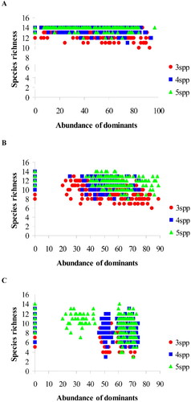

**Figure B11:**

Sensitivity analysis of the model of species richness and abundance score of dominant ants to changing the value of the mean abundance threshold. Conducted using *Competition 1*, 15 baits only, and an even bait distribution. *A*, Even abundance frequency distribution; *B*, realistic abundance frequency distribution; *C*, skewed abundance frequency distribution.

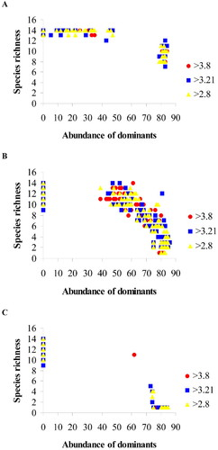

**Figure B12:**

Sensitivity analysis of the model of species richness and abundance score of dominant ants to changing the value of the monopolization threshold. Conducted using *Competition 1*, 15 baits only, and an even bait distribution. *A*, Even abundance frequency distribution; *B*, realistic abundance frequency distribution; *C*, skewed abundance frequency distribution.

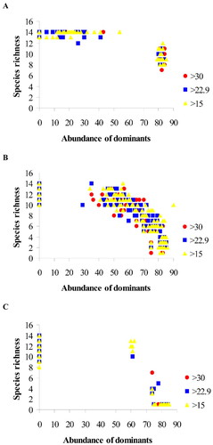

**Figure B13:**

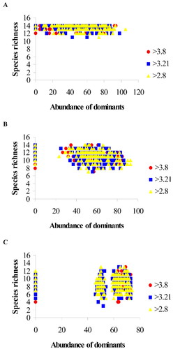

**Figure B14:**

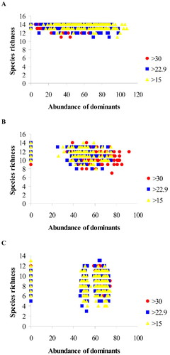

**Figure B15:**

Effect of increasing recruitment factor (*RF*) on modeled dominance–species richness relationship. In this case, there is a species with low abundance that recruits better than all other species. Modeled using *Competition 1*, 15 baits only, and an even bait distribution. Each data set is the result of 100 iterations of the model. *A*, Even abundance frequency distribution; *B*, realistic abundance frequency distribution; *C*, skewed abundance frequency distribution.

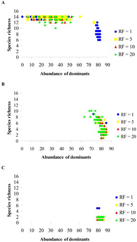

**Figure B16:**

Effect of increasing recruitment factor (*RF*) on modeled dominance–species richness relationship. In this case, there is a species with low abundance that recruits better than all other species. Modeled using *Competition 1*, 15 baits only, and a Poisson bait distribution. Each data set is the result of 100 iterations of the model. *A*, Even abundance frequency distribution; *B*, realistic abundance frequency distribution; *C*, skewed abundance frequency distribution.

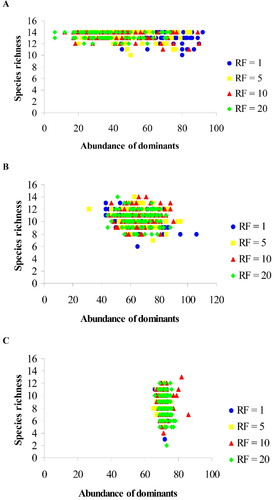

**Figure B17:**

Effect of increasing recruitment factor (*RF*) on modeled dominance–species richness relationship. In this case, there is a species with high abundance that has impaired recruitment compared to all the other species. Modeled using *Competition 1*, 15 baits only, and an even bait distribution. Each data set is the result of 100 iterations of the model. *A*, Even abundance frequency distribution; *B*, realistic abundance frequency distribution; *C*, skewed abundance frequency distribution.

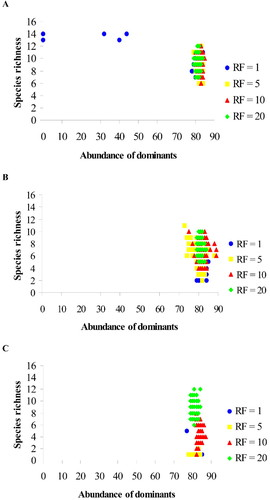

**Figure B18:**

Effect of increasing recruitment factor (*RF*) on modeled dominance–species richness relationship. In this case, there is a species with high abundance that has impaired recruitment compared to all the other species. Modeled using *Competition 1*, 15 baits only, and a Poisson bait distribution. Each data set is the result of 100 iterations of the model. *A*, Even abundance frequency distribution; *B*, realistic abundance frequency distribution; *C*, skewed abundance frequency distribution.

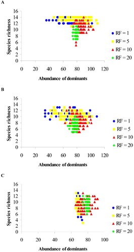

Appendix A: Modeling Ants at Baits

Appendix B: Figures

[figure not shown]

#### Article DOI

  https://doi.org/10.1086/428292

#### History

  - Received November 27, 2003
  - Accepted September 23, 2004
  - Published online March 8, 2005

  © 2005 by The University of Chicago.

[figure not shown]

    Ecological Entomology 1: .

    Journal of Animal Ecology 10: .

    Oecologia 2: .

    PeerJ : .

    IOP Conference Series: Earth and Environmental Science : .

    Environmental Entomology 3: .

    Austral Entomology 1: .

    Insectes Sociaux 1: .

    PeerJ : .

    Ecology and Evolution 23: .

    Basic and Applied Ecology 1: .

    Ecology 1: .

    African Invertebrates 3: .

    Biological Conservation : .

    Journal of Biogeography 12: .

    Journal of Biogeography 12: .

    Ecological Entomology 5: .

    Biological Journal of the Linnean Society 2: .

    Forest Ecology and Management : .

    Ecological Entomology 2: .

    Austral Ecology 1: .

    Ecology 2: .

    Behavioral Ecology 6: .

    Journal of Insect Conservation 5: .

    Ecological Entomology 1: .

    Psyche: A Journal of Entomology : .

    Journal of Animal Ecology 1: .

    Austral Ecology 8: .

    Ecology 10: .

    Environmental Entomology 5: .

    Ecography 3: .

    Oecologia 1: .

    Biological Invasions 9: .

    Austral Ecology 3: .

    Oikos 3: .

    International Journal of Ecology : .

    African Journal of Ecology .

    Insectes Sociaux 2: .

    Journal of Animal Ecology 6: .

    Austral Ecology 7: .

    Journal of Insect Physiology 6: .

    Austral Ecology 2: .